# Green Book Section I.C.1.a — Flagged parcels

I.C.1.a flagged wellfield profiles — percentile framing, DTW context, and composition

Author

Inyo County Water Department

Published

September 30, 2026

I.C.1.a flagged wellfield parcels (`Cover_sig.counter > 5` or `Grass_sig.counter > 5`). Profiles summarize measurable change vs the 1984–1987 baseline — not cause. Full attributability: [I.C.1.b](https://icwd-attributability.vercel.app).

**How to interpret a profile**

Wellfield parcels below are I.C.1.a flagged when `Cover_sig.counter > 5` or `Grass_sig.counter > 5` (more than five consecutive years statistically below baseline for total perennial cover or grass). This is a sustained measurable flag under I.C.1.a—not a diagnosis of cause, and not Agreement “significance” under I.C.1.c. Profiles lead with percentile framing (current and baseline years ranked within each parcel’s own time series) and a valley-floor NMDS year path with that parcel’s mapped Green Book TYPE baseline cloud. NMDS distances represent movement through species-composition space (composition geometry / evidence only — not control matching); this informs the evidence picture without serving as the sole I.C.1.a gate. Screening is parcel-by-parcel; questions of causation belong to [I.C.1.b attributability analysis](https://icwd-attributability.vercel.app).

1. **Measurability:** the orange I.C.1.a flag marks a sustained statistical decrease in perennial cover or grass relative to the parcel’s baseline.
2. **Support / Not supported (sequential):** Support = decline evidence only — cover↓ and/or grass↓ vs baseline, and/or shrub↑ vs baseline (each metric gated independently; not all required). Sustained counters and percentile rows use the same sign gate. Grass↑, shrub↓, and high grass / still-Type-C proportions go to Not supported (type-stable / contrary). Shown one after the other — not attributability or cause findings.
3. **Hydrologic context:** DTW and precipitation describe water-table and climate conditions. A deeper water table may warrant further attributability analysis; a shallower water table does not by itself establish or rule out causation.
4. **Vegetation and composition:** NDVI is a chlorophyll-related vegetation index (Jul–Sep window noted under the NDVI table). NMDS maps the parcel’s year path on the shared valley-floor plane against its mapped TYPE baseline cloud; percentile summaries and lifeform proportions add complementary evidence. NMDS informs the evidence picture but is not the sole I.C.1.a gate.

The Technical Group may refine methods as field techniques, technology, and analytical understanding develop under Box I.C.1.a.ii.

**Parcel order** — north→south wellfields (optional)**

Ordered by wellfield, then latitude within wellfield. Full table: Evaluate change. Map: Evaluate change — map.

## Parcel profiles

Profiling **13** wellfield parcels on the I.C.1.a flagged list (cover or grass statistically below baseline for more than 5 years).

### Laws — Parcel FSL044

**Support** = *decline evidence only* (cover↓ / grass↓ / shrub↑ vs baseline; sustained counters and percentile rows on the same sign gate). **Not supported** = type-stable / contrary signals (grass↑ / shrub↓ / cover↑; high grass / still-Type-C proportions; DTW & NDVI context). Not attributability or cause (see I.C.1.b).

Support (decline evidence)

#### Change vs baseline

|  | current | baseline | Δ |
| --- | --- | --- | --- |
| Cover | 47.8% | 69.1% | -21.3 pp |
| Grass | 33.7% | 68.4% | -34.7 pp |
| Shrub | 9.8% | 0.0% | +9.8 pp |

#### Sustained counters

Cover15 years below baselineI.C.1.a sustained-change screen

Grass16 years below baselineI.C.1.a sustained-change screen

#### Percentile rank

|  | current | baseline | Δ |
| --- | --- | --- | --- |
| Cover | 79 | 100 | -21 pct pts |
| Grass | 79 | 100 | -21 pct pts |
| Shrub | 79 | 4 | +75 pct pts |

Not supported (type-stable / contrary)

#### Perennial proportions (type-stable)

Grass70% of perennial cover

Shrub20% of perennial cover

#### Hydrologic context

DTW (ft BGS)current 4.4baseline 8.0Δ -3.6 ft (shallower)

#### NDVI vegetation index (baseline validity)

| Period | NDVI |
| --- | --- |
| Most recent (2026) | 0.293 |
| Baseline (1987) | 0.302 |
| Δ (recent − baseline) | -0.009 |

[Jul 15–Sep 15 aggregate; roughly two months after the June–late-July LPT sampling window.]

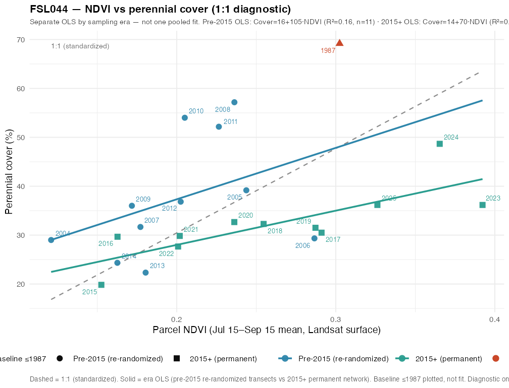

NDVI↔︎cover 1:1 diagnostic with separate OLS for pre-2015 (re-randomized) vs 2015+ (permanent); dashed = standardized 1:1. Unexpected baseline offset → investigate baseline validity.

Next steps

- Depth-to-water (DTW) is currently shallower than the 1987 baseline measurement on this parcel. In plain terms, the water table is closer to the surface than it was at the 1987 baseline measurement. The Green Book “adequacy-for-type” hydro screen asks whether depth is too deep for the mapped vegetation type; a shallower reading does not, by itself, push that screen. It also does not prove or disprove pumping as a cause — it only means hydrology alone is not the red flag here. Still check composition change, baseline quality (including NDVI↔︎cover residuals), and other I.C.1.b factors before causal language.
- NDVI↔︎cover diagnostic (plot in the margin / NDVI card): 1987 baseline cover sits well above the parcel’s NDVI–cover fit (large positive residual). That pattern is a flag to investigate baseline validity (possible inflated baseline), not a causal conclusion about pumping.
- Pre-2015 vs 2015+ permanent-transect network eras differ in sampling design; do not over-interpret single-year NDVI/cover mismatches across that break.
- Meadow-dominant composition and currently shallow DTW are important context for any later attributability discussion on this parcel.
- Measurability under Box I.C.1.a.ii is already established for this parcel (sustained cover and/or grass below baseline). Causation is a separate step: I.C.1.b attributability requires control comparisons, rainfall, land use, and other stressors before any “but for pumping / surface-water practice” conclusion.

Type-stable notes (also under Not supported)

- Grass still ~70% of perennial cover (reinventory mean ~71%; range 56–96%). Meadow/grass dominance supports vegetation-type stability — not a shrub-encroachment alarm.
- Shrub share below the Type C→B ≥80% reference — high-shrub alarm does not apply at present.

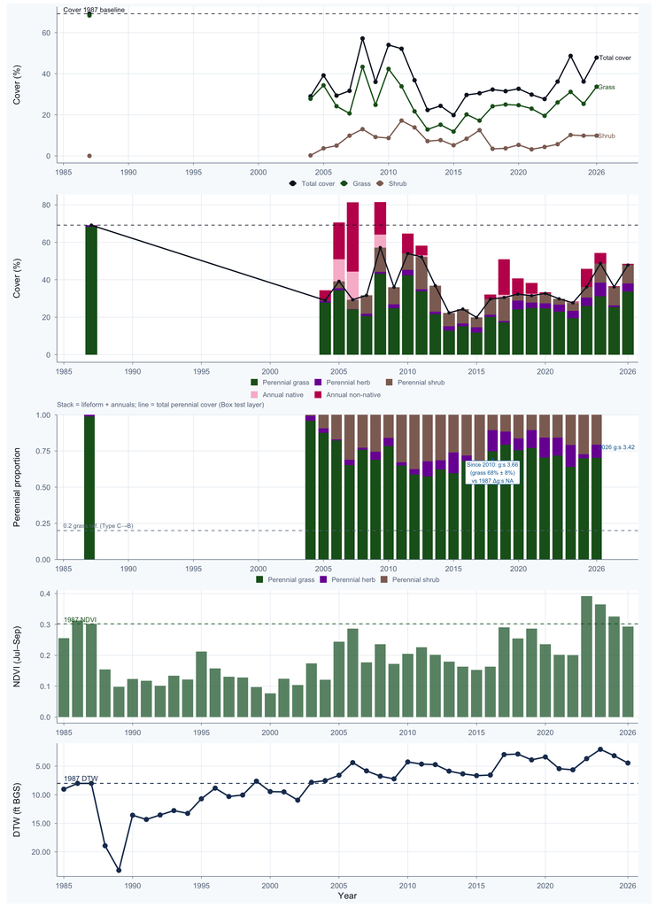

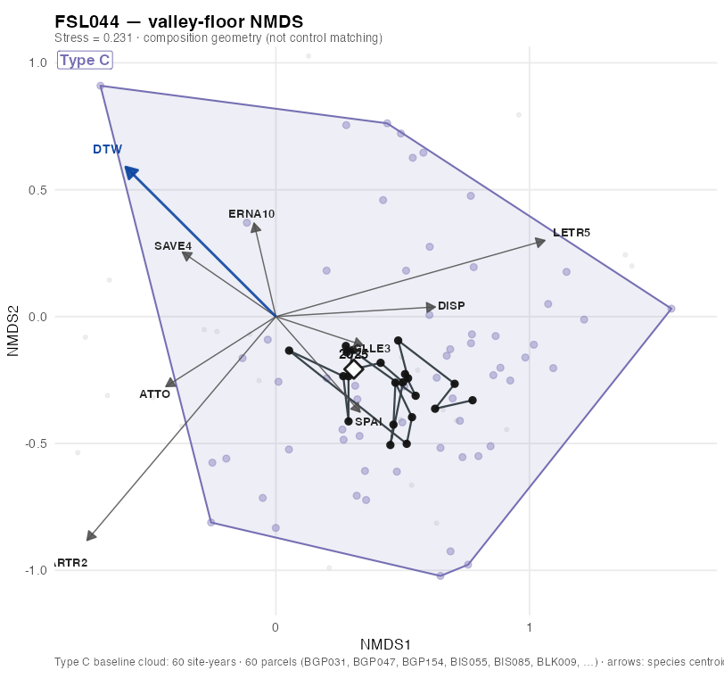

**NMDS path** — valley-floor composition geometry; Type callout = mapped GB type; caption lists same-TYPE cloud n (site-years / parcels); arrows = dominant species centroids + DTW gradient (not control matching).

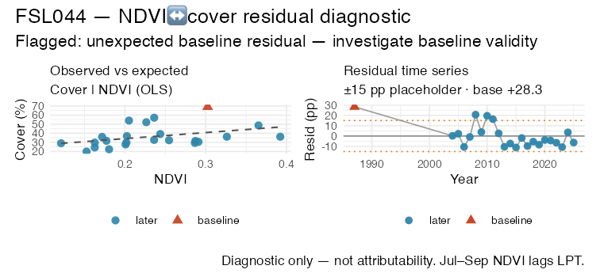

**NDVI residual** — observed vs expected Cover|NDVI and residual time series; unexpected baseline offset → investigate baseline validity.

### Laws — Parcel FSL054

**Support** = *decline evidence only* (cover↓ / grass↓ / shrub↑ vs baseline; sustained counters and percentile rows on the same sign gate). **Not supported** = type-stable / contrary signals (grass↑ / shrub↓ / cover↑; high grass / still-Type-C proportions; DTW & NDVI context). Not attributability or cause (see I.C.1.b).

Support (decline evidence)

#### Change vs baseline

|  | current | baseline | Δ |
| --- | --- | --- | --- |
| Cover | 51.3% | 90.0% | -38.7 pp |

#### Sustained counters

Cover21 years below baselineI.C.1.a sustained-change screen

#### Percentile rank

|  | current | baseline | Δ |
| --- | --- | --- | --- |
| Cover | 27 | 100 | -73 pct pts |

Not supported (type-stable / contrary)

#### Change vs baseline

|  | current | baseline | Δ |
| --- | --- | --- | --- |
| Grass | 37.5% | 9.9% | +27.6 pp |
| Shrub | 4.0% | 73.8% | -69.8 pp |

#### Sustained counters

Grass0 years below baseline

#### Percentile rank

|  | current | baseline | Δ |
| --- | --- | --- | --- |
| Grass | 32 | 5 | +27 pct pts |
| Shrub | 32 | 100 | -68 pct pts |

#### Perennial proportions (type-stable)

Grass70% of perennial cover

Shrub10% of perennial cover

#### Hydrologic context

DTW (ft BGS)current 5.2baseline 12.5Δ -7.3 ft (shallower)

#### NDVI vegetation index (baseline validity)

| Period | NDVI |
| --- | --- |
| Most recent (2026) | 0.524 |
| Baseline (1985) | 0.522 |
| Δ (recent − baseline) | +0.002 |

[Jul 15–Sep 15 aggregate; roughly two months after the June–late-July LPT sampling window.]

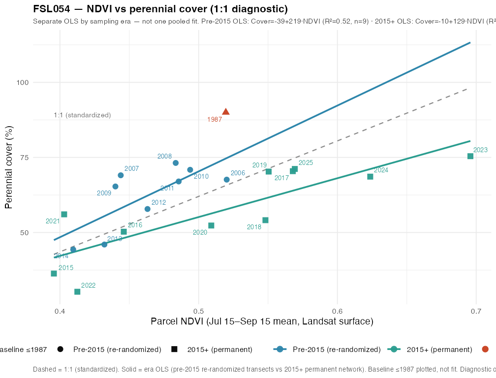

NDVI↔︎cover 1:1 diagnostic with separate OLS for pre-2015 (re-randomized) vs 2015+ (permanent); dashed = standardized 1:1. Unexpected baseline offset → investigate baseline validity.

Next steps

- Special consideration — riparian history: this stand was historically riparian scrub / coyote willow (Type D character). After pumping-related die-off, fire, and river-level / irrigation practices that no longer support Type D, the vegetation is now more akin to Type C meadow. Treat mapped type vs present composition as an interpretive context, not a simple C→B shrub-encroachment story.
- Composition differs from the mapped type because of that riparian history; use those differences for interpretation and future management analysis, not as an automatic Type C alarm.
- Naming note: FSL* parcel codes here are Laws wellfield parcels along the Owens River mainstem — not Fish Slough.
- Depth-to-water (DTW) is currently shallower than the 1985 baseline measurement on this parcel. In plain terms, the water table is closer to the surface than it was at the 1985 baseline measurement. The Green Book “adequacy-for-type” hydro screen asks whether depth is too deep for the mapped vegetation type; a shallower reading does not, by itself, push that screen. It also does not prove or disprove pumping as a cause — it only means hydrology alone is not the red flag here. Still check composition change, baseline quality (including NDVI↔︎cover residuals), and other I.C.1.b factors before causal language.

Type-stable notes (also under Not supported)

- Grass still ~73% of perennial cover (reinventory mean ~69%; range 11–83%). Meadow/grass dominance supports vegetation-type stability — not a shrub-encroachment alarm.

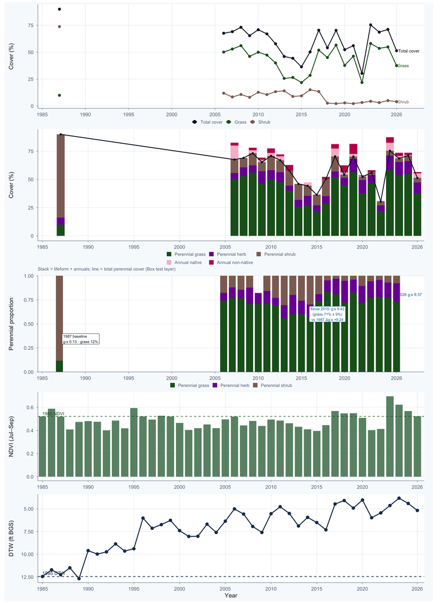

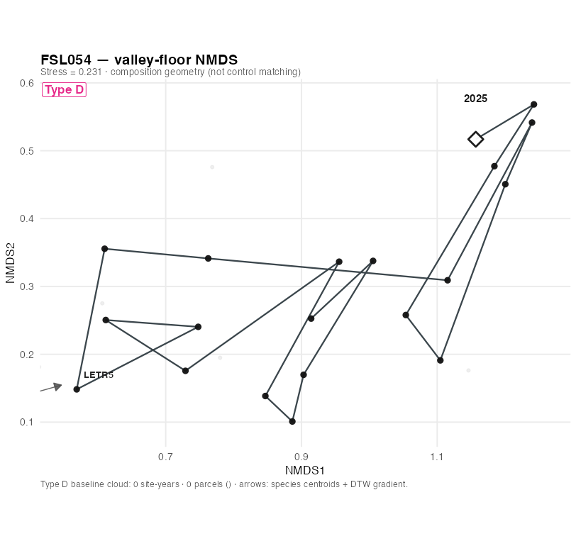

**NMDS path** — valley-floor composition geometry; Type callout = mapped GB type; caption lists same-TYPE cloud n (site-years / parcels); arrows = dominant species centroids + DTW gradient (not control matching).

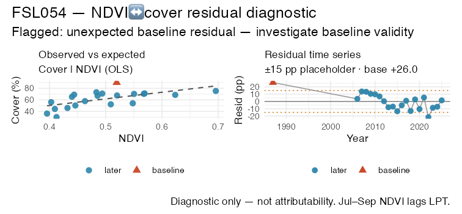

**NDVI residual** — observed vs expected Cover|NDVI and residual time series; unexpected baseline offset → investigate baseline validity.

### Laws — Parcel LAW035

**Support** = *decline evidence only* (cover↓ / grass↓ / shrub↑ vs baseline; sustained counters and percentile rows on the same sign gate). **Not supported** = type-stable / contrary signals (grass↑ / shrub↓ / cover↑; high grass / still-Type-C proportions; DTW & NDVI context). Not attributability or cause (see I.C.1.b).

Support (decline evidence)

#### Change vs baseline

|  | current | baseline | Δ |
| --- | --- | --- | --- |
| Cover | 8.2% | 33.1% | -24.9 pp |
| Grass | 4.5% | 27.3% | -22.8 pp |
| Shrub | 2.5% | 0.0% | +2.5 pp |

#### Sustained counters

Cover2 years below baseline

Grass7 years below baselineI.C.1.a sustained-change screen

#### Percentile rank

|  | current | baseline | Δ |
| --- | --- | --- | --- |
| Cover | 64 | 96 | -32 pct pts |
| Grass | 64 | 100 | -36 pct pts |
| Shrub | 96 | 4 | +92 pct pts |

Not supported (type-stable / contrary)

#### Perennial proportions (type-stable)

Grass50% of perennial cover

Shrub30% of perennial cover

#### Hydrologic context

DTW (ft BGS)current 19.5baseline 19.4Δ +0.2 ft (deeper)

#### NDVI vegetation index (baseline validity)

| Period | NDVI |
| --- | --- |
| Most recent (2026) | 0.175 |
| Baseline (1987) | 0.129 |
| Δ (recent − baseline) | +0.045 |

**NDVI evidence problematic.** NDVI evidence problematic: baseline Cover residual +25.6 pp vs NDVI–cover fit (threshold ±15 pp, later sd=3.3). Investigate baseline validity (voracity of baseline) before leaning on NDVI↔︎cover.

[Jul 15–Sep 15 aggregate; roughly two months after the June–late-July LPT sampling window.]

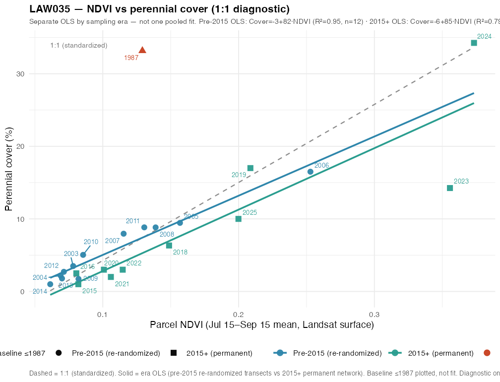

NDVI↔︎cover 1:1 diagnostic with separate OLS for pre-2015 (re-randomized) vs 2015+ (permanent); dashed = standardized 1:1. Unexpected baseline offset → investigate baseline validity.

Next steps

- Depth-to-water (DTW) is currently deeper than the 1987 baseline measurement (water table farther below ground). If that deeper condition is sustained and looks incompatible with mapped Type C, prioritize I.C.1.b water-table / soil-water factors in attributability analysis — together with rainfall, land use, and other stressors. Deeper DTW is context for causation review, not a final “but for” finding by itself.

Type-stable notes (also under Not supported)

- Shrub share below the Type C→B ≥80% reference — high-shrub alarm does not apply at present.

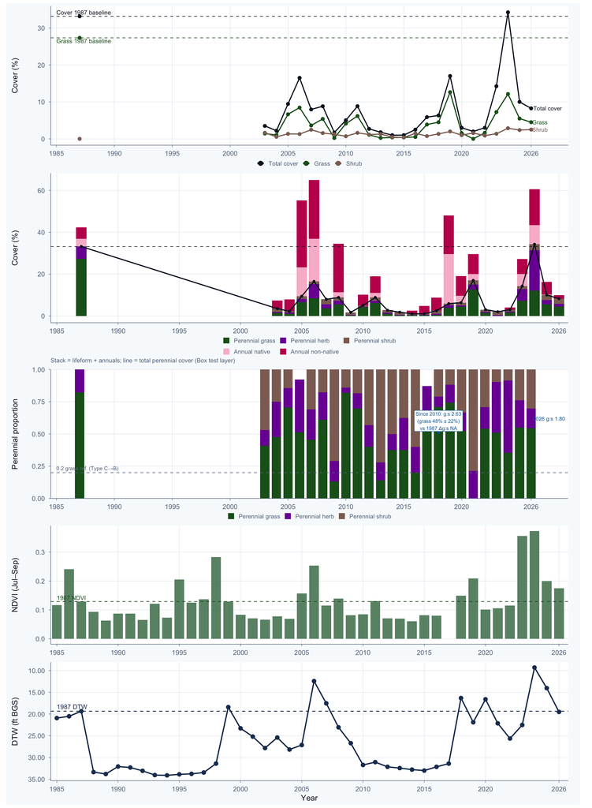

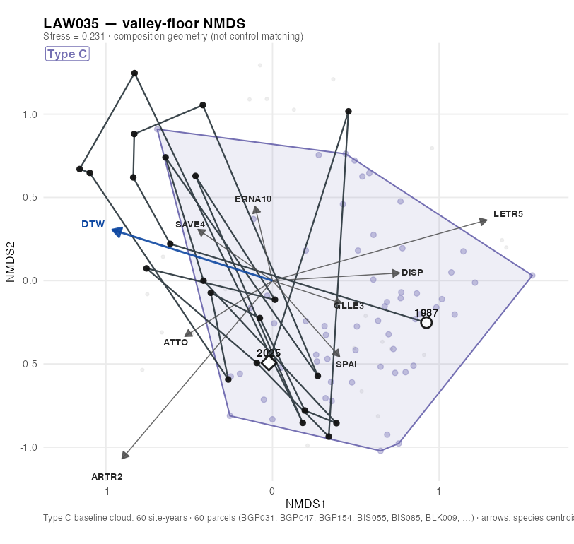

**NMDS path** — valley-floor composition geometry; Type callout = mapped GB type; caption lists same-TYPE cloud n (site-years / parcels); arrows = dominant species centroids + DTW gradient (not control matching).

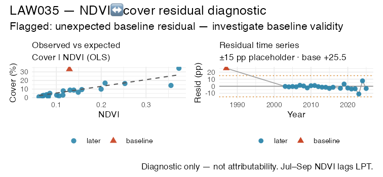

**NDVI residual** — observed vs expected Cover|NDVI and residual time series; unexpected baseline offset → investigate baseline validity.

### Laws — Parcel LAW043

**Support** = *decline evidence only* (cover↓ / grass↓ / shrub↑ vs baseline; sustained counters and percentile rows on the same sign gate). **Not supported** = type-stable / contrary signals (grass↑ / shrub↓ / cover↑; high grass / still-Type-C proportions; DTW & NDVI context). Not attributability or cause (see I.C.1.b).

Support (decline evidence)

#### Change vs baseline

|  | current | baseline | Δ |
| --- | --- | --- | --- |
| Cover | 12.2% | 61.1% | -48.9 pp |
| Grass | 5.1% | 60.0% | -54.9 pp |
| Shrub | 6.0% | 1.1% | +4.9 pp |

#### Sustained counters

Cover24 years below baselineI.C.1.a sustained-change screen

Grass24 years below baselineI.C.1.a sustained-change screen

#### Percentile rank

|  | current | baseline | Δ |
| --- | --- | --- | --- |
| Cover | 60 | 100 | -40 pct pts |
| Grass | 80 | 100 | -20 pct pts |
| Shrub | 56 | 4 | +52 pct pts |

Not supported (type-stable / contrary)

#### Perennial proportions (type-stable)

Grass40% of perennial cover

Shrub50% of perennial cover

#### Hydrologic context

DTW (ft BGS)current 14.2baseline 9.6Δ +4.7 ft (deeper)

#### NDVI vegetation index (baseline validity)

| Period | NDVI |
| --- | --- |
| Most recent (2026) | 0.187 |
| Baseline (1987) | 0.161 |
| Δ (recent − baseline) | +0.026 |

**NDVI evidence problematic.** NDVI evidence problematic: baseline Cover residual +49.0 pp vs NDVI–cover fit (threshold ±15 pp, later sd=3.1). Investigate baseline validity (voracity of baseline) before leaning on NDVI↔︎cover.

[Jul 15–Sep 15 aggregate; roughly two months after the June–late-July LPT sampling window.]

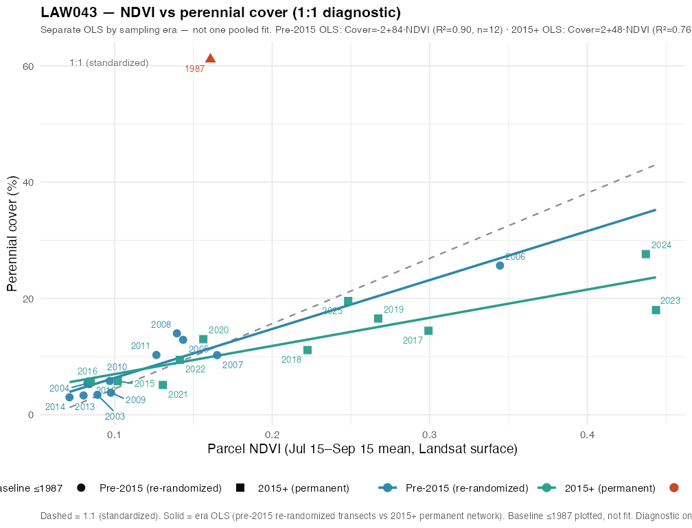

NDVI↔︎cover 1:1 diagnostic with separate OLS for pre-2015 (re-randomized) vs 2015+ (permanent); dashed = standardized 1:1. Unexpected baseline offset → investigate baseline validity.

Next steps

- Depth-to-water (DTW) is currently deeper than the 1987 baseline measurement (water table farther below ground). If that deeper condition is sustained and looks incompatible with mapped Type E, prioritize I.C.1.b water-table / soil-water factors in attributability analysis — together with rainfall, land use, and other stressors. Deeper DTW is context for causation review, not a final “but for” finding by itself.
- Measurability under Box I.C.1.a.ii is already established for this parcel (sustained cover and/or grass below baseline). Causation is a separate step: I.C.1.b attributability requires control comparisons, rainfall, land use, and other stressors before any “but for pumping / surface-water practice” conclusion.

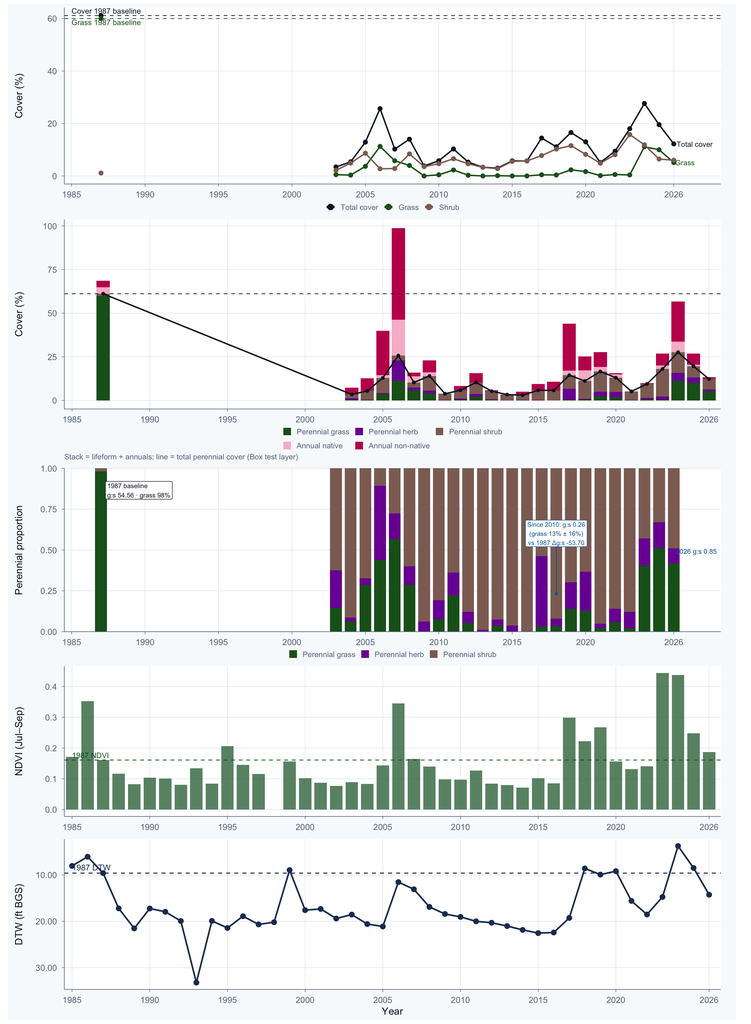

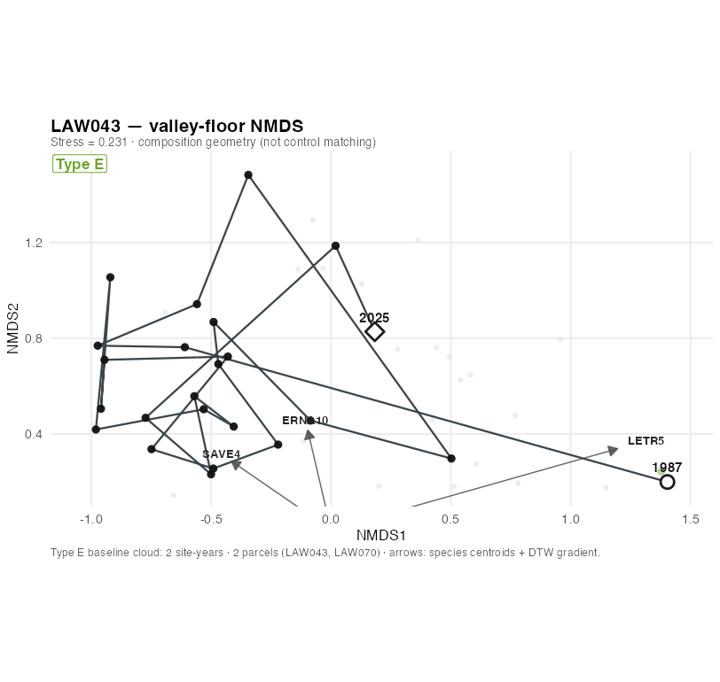

**NMDS path** — valley-floor composition geometry; Type callout = mapped GB type; caption lists same-TYPE cloud n (site-years / parcels); arrows = dominant species centroids + DTW gradient (not control matching).

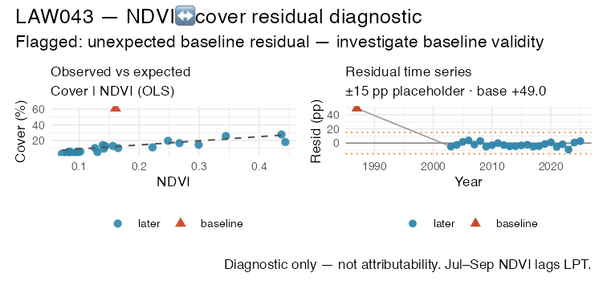

**NDVI residual** — observed vs expected Cover|NDVI and residual time series; unexpected baseline offset → investigate baseline validity.

### Laws — Parcel LAW052

**Support** = *decline evidence only* (cover↓ / grass↓ / shrub↑ vs baseline; sustained counters and percentile rows on the same sign gate). **Not supported** = type-stable / contrary signals (grass↑ / shrub↓ / cover↑; high grass / still-Type-C proportions; DTW & NDVI context). Not attributability or cause (see I.C.1.b).

Support (decline evidence)

#### Change vs baseline

|  | current | baseline | Δ |
| --- | --- | --- | --- |
| Cover | 11.9% | 27.9% | -16.0 pp |
| Grass | 0.4% | 22.4% | -22.0 pp |
| Shrub | 9.5% | 5.3% | +4.2 pp |

#### Sustained counters

Cover2 years below baseline

Grass31 years below baselineI.C.1.a sustained-change screen

#### Percentile rank

|  | current | baseline | Δ |
| --- | --- | --- | --- |
| Cover | 84 | 100 | -16 pct pts |
| Grass | 66 | 100 | -34 pct pts |
| Shrub | 78 | 44 | +34 pct pts |

#### Perennial proportions (type drift)

Grass0% of perennial cover

Shrub80% of perennial cover

Not supported (type-stable / contrary)

#### Hydrologic context

DTW (ft BGS)current 13.3baseline 9.5Δ +3.8 ft (deeper)

#### NDVI vegetation index (baseline validity)

| Period | NDVI |
| --- | --- |
| Most recent (2026) | 0.170 |
| Baseline (1987) | 0.143 |
| Δ (recent − baseline) | +0.027 |

**NDVI evidence problematic.** NDVI evidence problematic: baseline Cover residual +19.5 pp vs NDVI–cover fit (threshold ±15 pp, later sd=2.9). Investigate baseline validity (voracity of baseline) before leaning on NDVI↔︎cover.

[Jul 15–Sep 15 aggregate; roughly two months after the June–late-July LPT sampling window.]

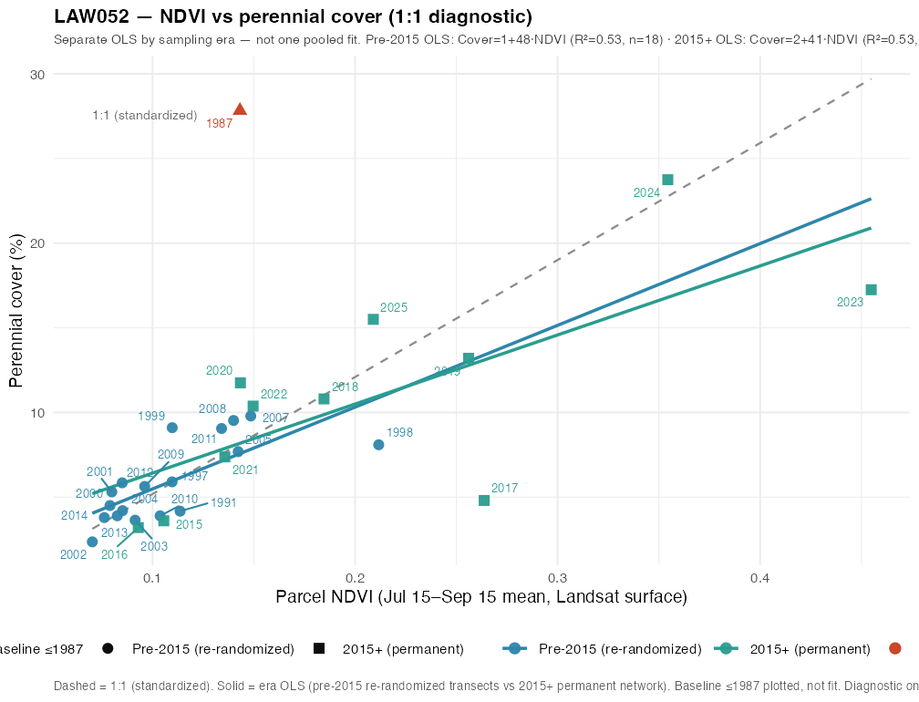

NDVI↔︎cover 1:1 diagnostic with separate OLS for pre-2015 (re-randomized) vs 2015+ (permanent); dashed = standardized 1:1. Unexpected baseline offset → investigate baseline validity.

Next steps

- Depth-to-water (DTW) is currently deeper than the 1987 baseline measurement (water table farther below ground). If that deeper condition is sustained and looks incompatible with mapped Type C, prioritize I.C.1.b water-table / soil-water factors in attributability analysis — together with rainfall, land use, and other stressors. Deeper DTW is context for causation review, not a final “but for” finding by itself.

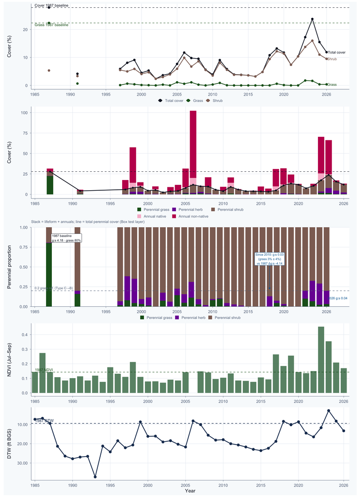

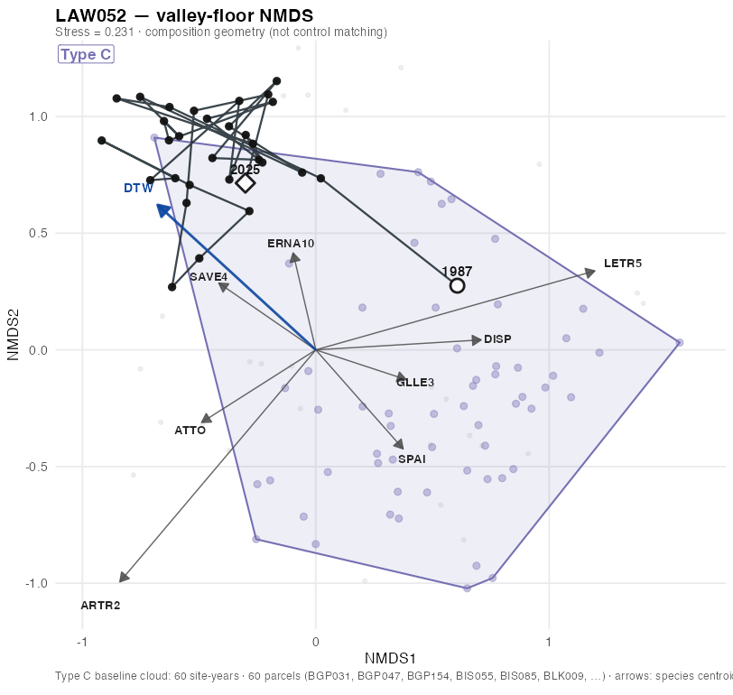

**NMDS path** — valley-floor composition geometry; Type callout = mapped GB type; caption lists same-TYPE cloud n (site-years / parcels); arrows = dominant species centroids + DTW gradient (not control matching).

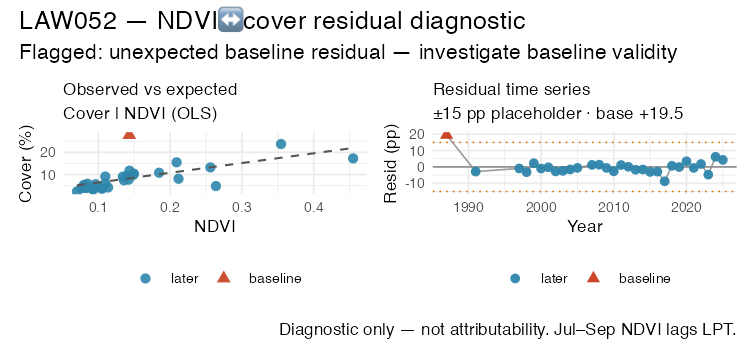

**NDVI residual** — observed vs expected Cover|NDVI and residual time series; unexpected baseline offset → investigate baseline validity.

### Laws — Parcel LAW082

**Support** = *decline evidence only* (cover↓ / grass↓ / shrub↑ vs baseline; sustained counters and percentile rows on the same sign gate). **Not supported** = type-stable / contrary signals (grass↑ / shrub↓ / cover↑; high grass / still-Type-C proportions; DTW & NDVI context). Not attributability or cause (see I.C.1.b).

Support (decline evidence)

#### Change vs baseline

|  | current | baseline | Δ |
| --- | --- | --- | --- |
| Cover | 14.2% | 16.3% | -2.1 pp |
| Grass | 0.0% | 5.7% | -5.7 pp |
| Shrub | 14.0% | 9.7% | +4.3 pp |

#### Sustained counters

Grass31 years below baselineI.C.1.a sustained-change screen

#### Percentile rank

|  | current | baseline | Δ |
| --- | --- | --- | --- |
| Cover | 88 | 91 | -3 pct pts |
| Grass | 44 | 100 | -56 pct pts |
| Shrub | 91 | 72 | +19 pct pts |

#### Perennial proportions (type drift)

Grass0% of perennial cover

Shrub100% of perennial cover

Not supported (type-stable / contrary)

#### Sustained counters

Cover0 years below baseline

#### Hydrologic context

DTW (ft BGS)current 13.0baseline 11.1Δ +1.9 ft (deeper)

#### NDVI vegetation index

| Period | NDVI |
| --- | --- |
| Most recent (2026) | 0.160 |
| Baseline (1987) | 0.117 |
| Δ (recent − baseline) | +0.043 |

Baseline Cover residual vs NDVI–cover fit: +8.5 pp (placeholder screen ±15 pp).

[Jul 15–Sep 15 aggregate; roughly two months after the June–late-July LPT sampling window.]

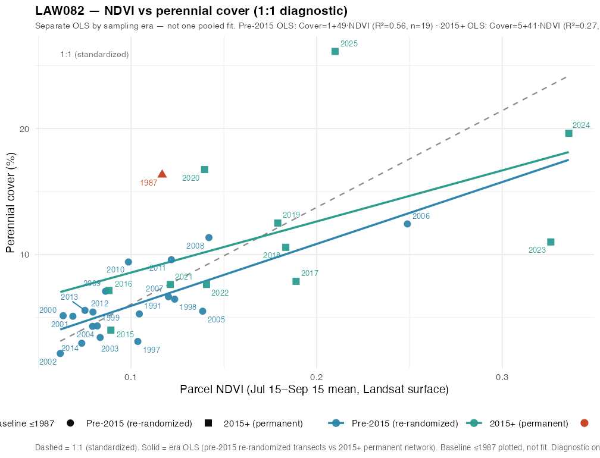

NDVI↔︎cover 1:1 diagnostic with separate OLS for pre-2015 (re-randomized) vs 2015+ (permanent); dashed = standardized 1:1. Unexpected baseline offset → investigate baseline validity.

Next steps

- Depth-to-water (DTW) is currently deeper than the 1987 baseline measurement (water table farther below ground). If that deeper condition is sustained and looks incompatible with mapped Type C, prioritize I.C.1.b water-table / soil-water factors in attributability analysis — together with rainfall, land use, and other stressors. Deeper DTW is context for causation review, not a final “but for” finding by itself.

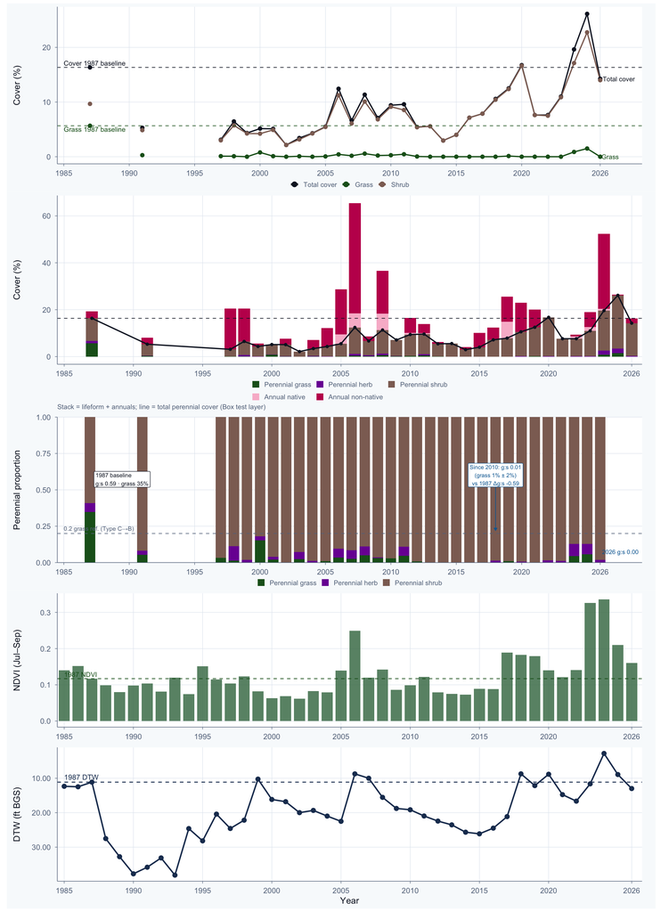

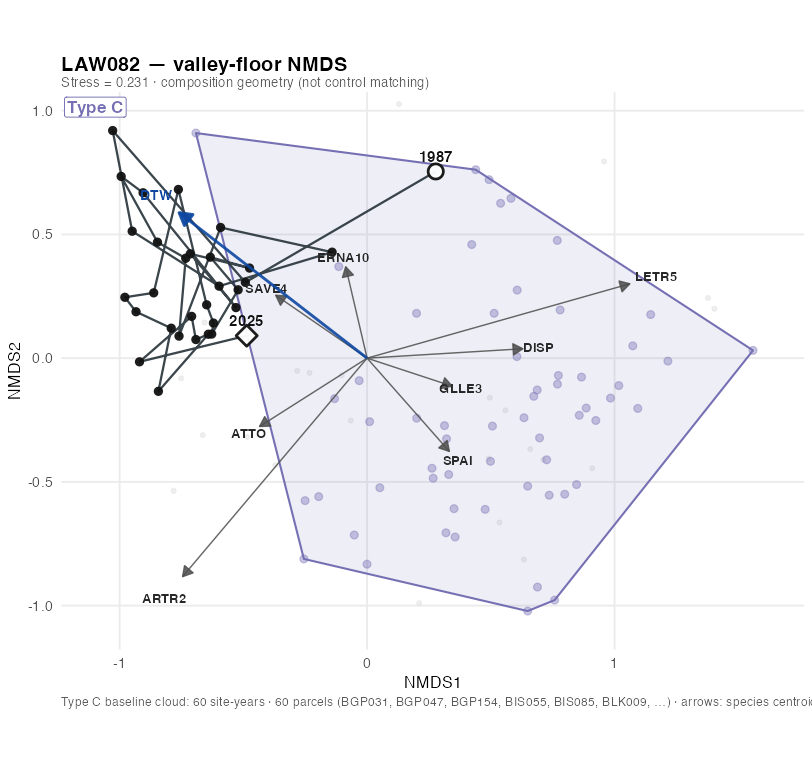

**NMDS path** — valley-floor composition geometry; Type callout = mapped GB type; caption lists same-TYPE cloud n (site-years / parcels); arrows = dominant species centroids + DTW gradient (not control matching).

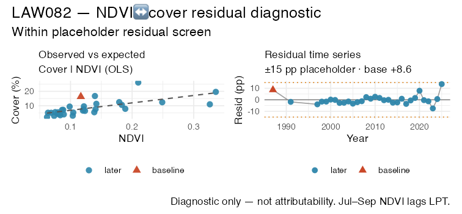

**NDVI residual** — observed vs expected Cover|NDVI and residual time series; unexpected baseline offset → investigate baseline validity.

### Big Pine — Parcel FSP006

**Support** = *decline evidence only* (cover↓ / grass↓ / shrub↑ vs baseline; sustained counters and percentile rows on the same sign gate). **Not supported** = type-stable / contrary signals (grass↑ / shrub↓ / cover↑; high grass / still-Type-C proportions; DTW & NDVI context). Not attributability or cause (see I.C.1.b).

Support (decline evidence)

#### Change vs baseline

|  | current | baseline | Δ |
| --- | --- | --- | --- |
| Grass | 5.0% | 21.2% | -16.2 pp |
| Shrub | 22.4% | 2.5% | +19.9 pp |

#### Sustained counters

Grass36 years below baselineI.C.1.a sustained-change screen

#### Percentile rank

|  | current | baseline | Δ |
| --- | --- | --- | --- |
| Grass | 81 | 100 | -19 pct pts |
| Shrub | 89 | 3 | +86 pct pts |

#### Perennial proportions (type drift)

Grass20% of perennial cover

Shrub80% of perennial cover

Not supported (type-stable / contrary)

#### Change vs baseline

|  | current | baseline | Δ |
| --- | --- | --- | --- |
| Cover | 27.4% | 23.8% | +3.6 pp |

#### Sustained counters

Cover0 years below baseline

#### Percentile rank

|  | current | baseline | Δ |
| --- | --- | --- | --- |
| Cover | 89 | 78 | +11 pct pts |

#### Hydrologic context

DTW (ft BGS)current 6.5baseline 12.1Δ -5.6 ft (shallower)

#### NDVI vegetation index

| Period | NDVI |
| --- | --- |
| Most recent (2026) | 0.195 |
| Baseline (1986) | 0.190 |
| Δ (recent − baseline) | +0.005 |

Baseline Cover residual vs NDVI–cover fit: -3.5 pp (placeholder screen ±15 pp).

[Jul 15–Sep 15 aggregate; roughly two months after the June–late-July LPT sampling window.]

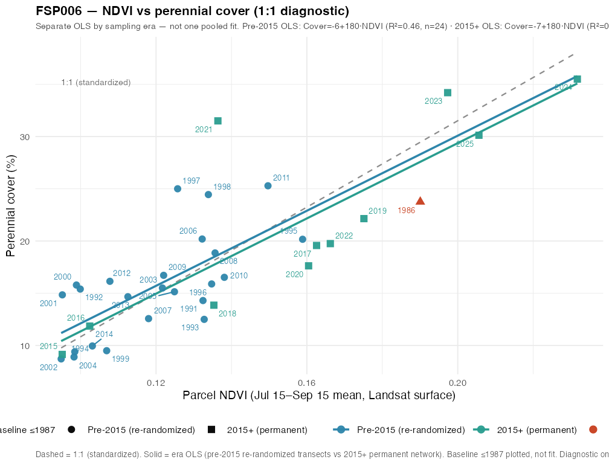

NDVI↔︎cover 1:1 diagnostic with separate OLS for pre-2015 (re-randomized) vs 2015+ (permanent); dashed = standardized 1:1. Unexpected baseline offset → investigate baseline validity.

Next steps

- Depth-to-water (DTW) is currently shallower than the 1986 baseline measurement on this parcel. In plain terms, the water table is closer to the surface than it was at the 1986 baseline measurement. The Green Book “adequacy-for-type” hydro screen asks whether depth is too deep for the mapped vegetation type; a shallower reading does not, by itself, push that screen. It also does not prove or disprove pumping as a cause — it only means hydrology alone is not the red flag here. Still check composition change, baseline quality (including NDVI↔︎cover residuals), and other I.C.1.b factors before causal language.

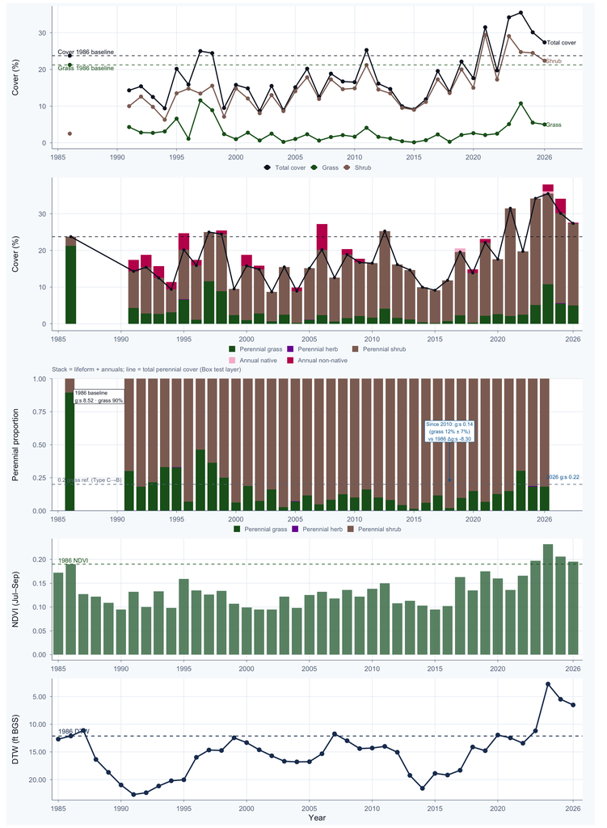

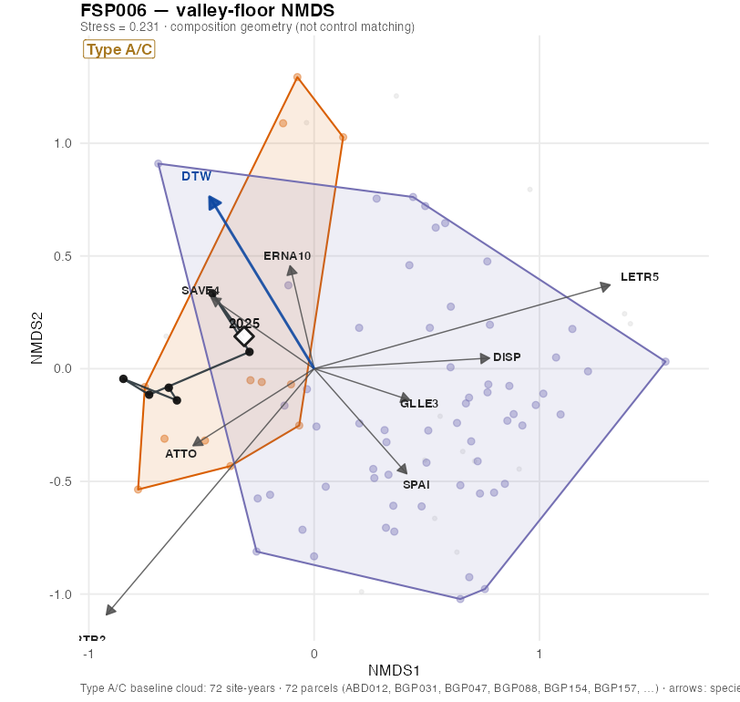

**NMDS path** — valley-floor composition geometry; Type callout = mapped GB type; caption lists same-TYPE cloud n (site-years / parcels); arrows = dominant species centroids + DTW gradient (not control matching).

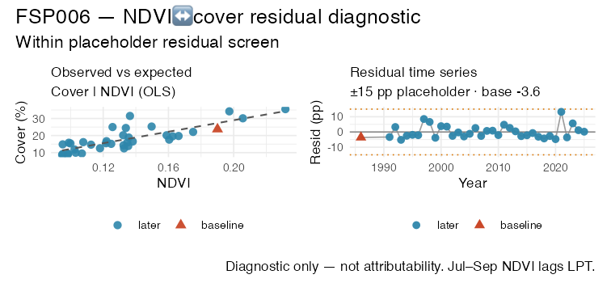

**NDVI residual** — observed vs expected Cover|NDVI and residual time series; unexpected baseline offset → investigate baseline validity.

### Taboose-Aberdeen — Parcel BLK142

**Support** = *decline evidence only* (cover↓ / grass↓ / shrub↑ vs baseline; sustained counters and percentile rows on the same sign gate). **Not supported** = type-stable / contrary signals (grass↑ / shrub↓ / cover↑; high grass / still-Type-C proportions; DTW & NDVI context). Not attributability or cause (see I.C.1.b).

Support (decline evidence)

#### Change vs baseline

|  | current | baseline | Δ |
| --- | --- | --- | --- |
| Grass | 10.8% | 17.3% | -6.5 pp |
| Shrub | 15.8% | 8.7% | +7.1 pp |

#### Sustained counters

Grass16 years below baselineI.C.1.a sustained-change screen

#### Percentile rank

|  | current | baseline | Δ |
| --- | --- | --- | --- |
| Grass | 68 | 100 | -32 pct pts |
| Shrub | 71 | 3 | +68 pct pts |

Not supported (type-stable / contrary)

#### Change vs baseline

|  | current | baseline | Δ |
| --- | --- | --- | --- |
| Cover | 26.7% | 26.0% | +0.7 pp |

#### Sustained counters

Cover0 years below baseline

#### Percentile rank

|  | current | baseline | Δ |
| --- | --- | --- | --- |
| Cover | 76 | 71 | +6 pct pts |

#### Perennial proportions (type-stable)

Grass40% of perennial cover

Shrub60% of perennial cover

#### Hydrologic context

DTW (ft BGS)current 4.2baseline 6.8Δ -2.6 ft (shallower)

#### NDVI vegetation index

| Period | NDVI |
| --- | --- |
| Most recent (2026) | 0.206 |
| Baseline (1987) | 0.118 |
| Δ (recent − baseline) | +0.088 |

Baseline Cover residual vs NDVI–cover fit: +1.0 pp (placeholder screen ±15 pp).

[Jul 15–Sep 15 aggregate; roughly two months after the June–late-July LPT sampling window.]

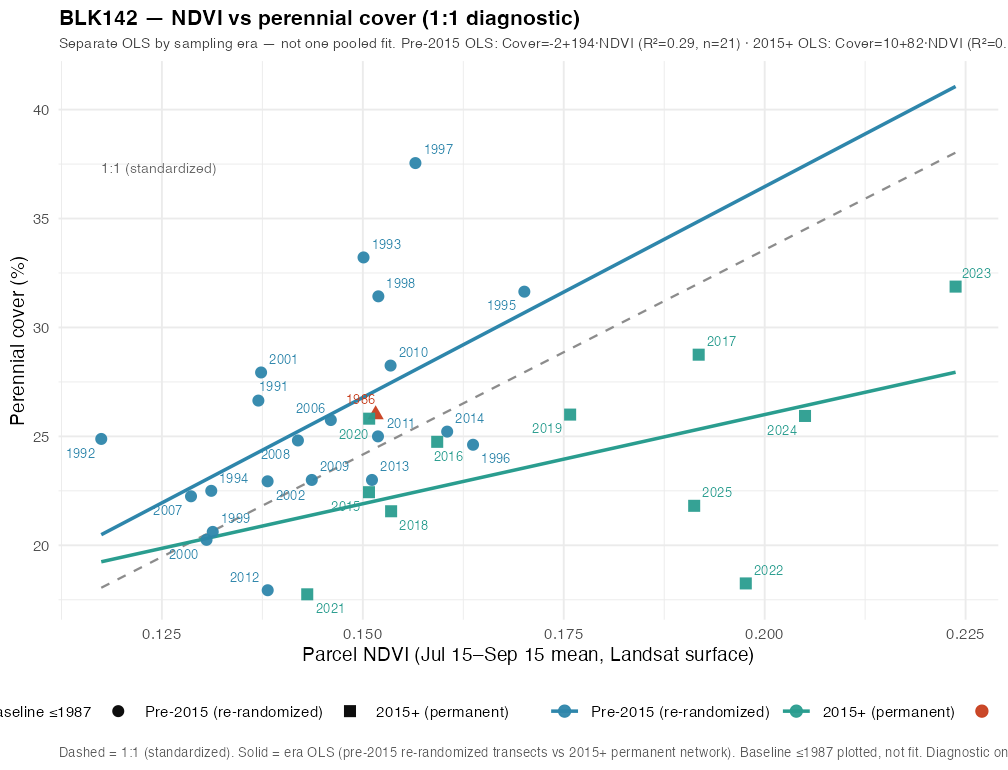

NDVI↔︎cover 1:1 diagnostic with separate OLS for pre-2015 (re-randomized) vs 2015+ (permanent); dashed = standardized 1:1. Unexpected baseline offset → investigate baseline validity.

Next steps

- Depth-to-water (DTW) is currently shallower than the 1987 baseline measurement on this parcel. In plain terms, the water table is closer to the surface than it was at the 1987 baseline measurement. The Green Book “adequacy-for-type” hydro screen asks whether depth is too deep for the mapped vegetation type; a shallower reading does not, by itself, push that screen. It also does not prove or disprove pumping as a cause — it only means hydrology alone is not the red flag here. Still check composition change, baseline quality (including NDVI↔︎cover residuals), and other I.C.1.b factors before causal language.

Type-stable notes (also under Not supported)

- Shrub share below the Type C→B ≥80% reference — high-shrub alarm does not apply at present.

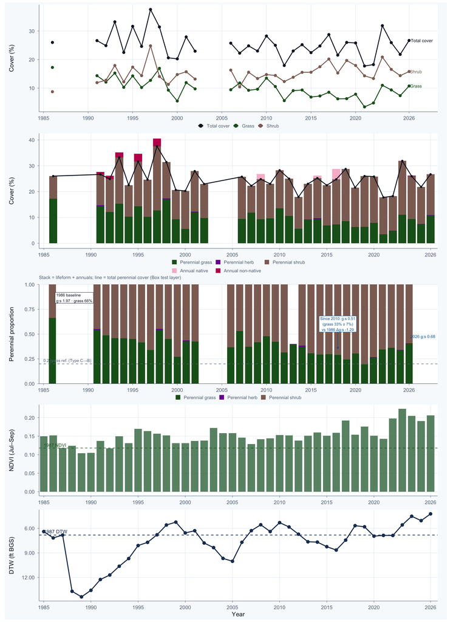

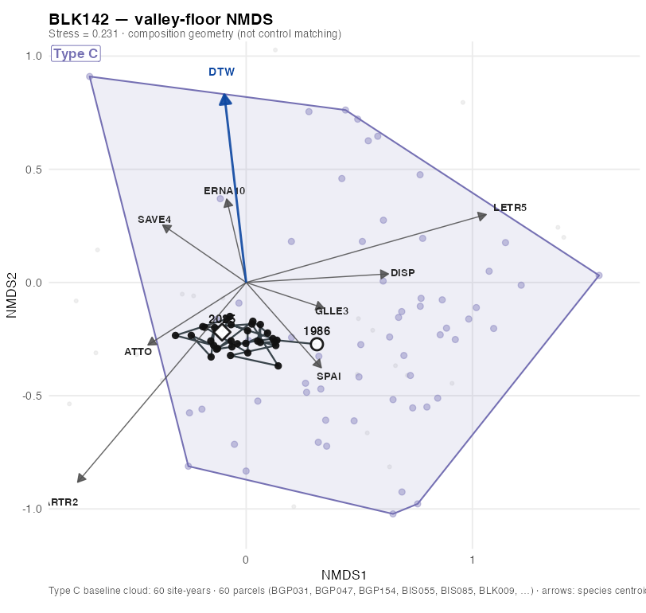

**NMDS path** — valley-floor composition geometry; Type callout = mapped GB type; caption lists same-TYPE cloud n (site-years / parcels); arrows = dominant species centroids + DTW gradient (not control matching).

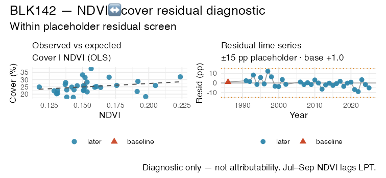

**NDVI residual** — observed vs expected Cover|NDVI and residual time series; unexpected baseline offset → investigate baseline validity.